# Project of Cricinfo

```python
from selenium import webdriver
from selenium.webdriver.chrome.service import Service
from webdriver_manager.chrome import ChromeDriverManager
from bs4 import BeautifulSoup
import re
import numpy as np
import pandas as pd

url = "https://stats.espncricinfo.com/ci/engine/stats/index.html?class=11;page=1;template=results;type=batting"

driver = webdriver.Chrome(service=Service(ChromeDriverManager().install()))

Player = []
Span = []
Matches = []
Innings = []
Runs = []
Ave= []
hs=[]
hundreds = []
fifties = []


for page in range(1, 10):
    url = f"https://stats.espncricinfo.com/ci/engine/stats/index.html?class=11;page={page};template=results;type=batting"
    driver.get(url)
    print(url)

    soup = BeautifulSoup(driver.page_source, "html.parser")
    rows = soup.find_all('tr', class_='data1')

    for row in rows:
        cols = row.find_all('td')
        if len(cols) > 0:
            Player.append(cols[0].text.strip())
            Span.append(cols[1].text.strip())
            Matches.append(cols[2].text.strip())
            Innings.append(cols[3].text.strip())
            Runs.append(cols[5].text.strip())
            hs.append(cols[6].text.strip())
            Ave.append(cols[7].text.strip())
            hundreds.append(cols[8].text.strip())
            fifties.append(cols[9].text.strip())
```

```
https://stats.espncricinfo.com/ci/engine/stats/index.html?class=11;page=1;template=results;type=batting
https://stats.espncricinfo.com/ci/engine/stats/index.html?class=11;page=2;template=results;type=batting
https://stats.espncricinfo.com/ci/engine/stats/index.html?class=11;page=3;template=results;type=batting
https://stats.espncricinfo.com/ci/engine/stats/index.html?class=11;page=4;template=results;type=batting
https://stats.espncricinfo.com/ci/engine/stats/index.html?class=11;page=5;template=results;type=batting
https://stats.espncricinfo.com/ci/engine/stats/index.html?class=11;page=6;template=results;type=batting
https://stats.espncricinfo.com/ci/engine/stats/index.html?class=11;page=7;template=results;type=batting
https://stats.espncricinfo.com/ci/engine/stats/index.html?class=11;page=8;template=results;type=batting
https://stats.espncricinfo.com/ci/engine/stats/index.html?class=11;page=9;template=results;type=batting
```

```python
dic={"Player":Player,"Span":Span,"Matches":Matches,"Innings":Innings,"Runs":Runs,"Average":Average,"highestscore":hs,"100s":hundreds,"50s":fifties}
```

```python
df=pd.DataFrame(dic)
df
```

[output not shown]

```python
df.duplicated().sum()
```

```
np.int64(0)
```

```python
df.info()
```

```
<class 'pandas.core.frame.DataFrame'>
RangeIndex: 450 entries, 0 to 449
Data columns (total 9 columns):
 #   Column        Non-Null Count  Dtype
---  ------        --------------  -----
 0   Player        450 non-null    object
 1   Span          450 non-null    object
 2   Matches       450 non-null    object
 3   Innings       450 non-null    object
 4   Runs          450 non-null    object
 5   Average       450 non-null    object
 6   highestscore  450 non-null    object
 7   100s          450 non-null    object
 8   50s           450 non-null    object
dtypes: object(9)
memory usage: 31.8+ KB
```

```python
df.to_csv("espncricket123.csv",index=False)
```

# Business Promblem

ESPN Cricinfo provides vast cricket statistics used by selectors, analysts, broadcasters, fantasy platforms, and fans. However, raw statistical tables alone do not easily reveal player consistency, performance trends, or relationships between key batting metrics.

Decision-makers need data-driven insights to:

Compare players objectively

Identify consistent and high-impact batters

Understand how career longevity affects performance

Analyze performance across different eras

# Promblem Statements

Cricket analytics platforms such as ESPN Cricinfo provide extensive historical batting data; however, the data is presented in raw tabular form, making it difficult to derive meaningful insights directly. There is a need to analyze and visualize this data to understand player performance, consistency, and trends over time. This project aims to apply exploratory data analysis and statistical techniques to identify key performance indicators and relationships among batting metrics.

# OBJECTIVES OF THE ANALYSIS

### Data Cleaning

```python
df.isnull().sum()
```

```
Player          0
Span            0
Matches         0
Innings         0
Runs            0
Average         0
highestscore    0
100s            0
50s             0
dtype: int64
```

```python
import pandas as pd
import numpy as np
df=pd.read_csv(r"C:\Users\chintha kalyan\innomatics\espncricket123.csv")
df
```

|  | Player | Span | Matches | Innings | Runs | Average | highestscore | 100s | 50s |
| --- | --- | --- | --- | --- | --- | --- | --- | --- | --- |
| 0 | SR Tendulkar (IND) | 1989-2013 | 664 | 782 | 34357 | 48.52 | 248* | 100 | 164 |
| 1 | KC Sangakkara (Asia/ICC/SL) | 2000-2015 | 594 | 666 | 28016 | 46.77 | 319 | 63 | 153 |
| 2 | V Kohli (IND) | 2008-2025 | 556 | 623 | 27975 | 52.58 | 254* | 84 | 145 |
| 3 | RT Ponting (AUS/ICC) | 1995-2012 | 560 | 668 | 27483 | 45.95 | 257 | 71 | 146 |
| 4 | DPMD Jayawardene (Asia/SL) | 1997-2015 | 652 | 725 | 25957 | 39.15 | 374 | 54 | 136 |
| ... | ... | ... | ... | ... | ... | ... | ... | ... | ... |
| 445 | BM McMillan (SA) | 1991-1998 | 116 | 114 | 2809 | 32.66 | 127 | 4 | 13 |
| 446 | GH Dockrell (IRE) | 2010-2025 | 284 | 197 | 2806 | 21.41 | 91* | 0 | 8 |
| 447 | Haris Sohail (PAK) | 2013-2023 | 75 | 84 | 2806 | 36.92 | 147 | 4 | 19 |
| 448 | MAK Pataudi (IND) | 1961-1975 | 46 | 83 | 2793 | 34.91 | 203* | 6 | 16 |
| 449 | Sabbir Rahman (BAN) | 2014-2022 | 125 | 128 | 2791 | 24.48 | 102 | 1 | 14 |

450 rows × 9 columns

```python
virat=df[df["Player"]=="V Kohli (IND)"].groupby("Player")["Runs"].sum()
print(virat)
```

```
Player
V Kohli (IND)    27975
Name: Runs, dtype: int64
```

```python
numeric_cols = [
    'Matches', 'Innings', 'Runs',
    'Average',
    '100s','50s'
]

for col in numeric_cols:
    df[col] = pd.to_numeric(df[col], errors='coerce')
```

```python
df['highestscore'] = (
    df['highestscore']
    .astype(str)
    .str.replace('*', '', regex=False)
    .replace('nan', None)
    .astype(float)
)
```

```python
df.dtypes
```

[output not shown]

## Visulization

```python
import pandas as pd
import matplotlib.pyplot as plt
import seaborn as sns
```

# univarient

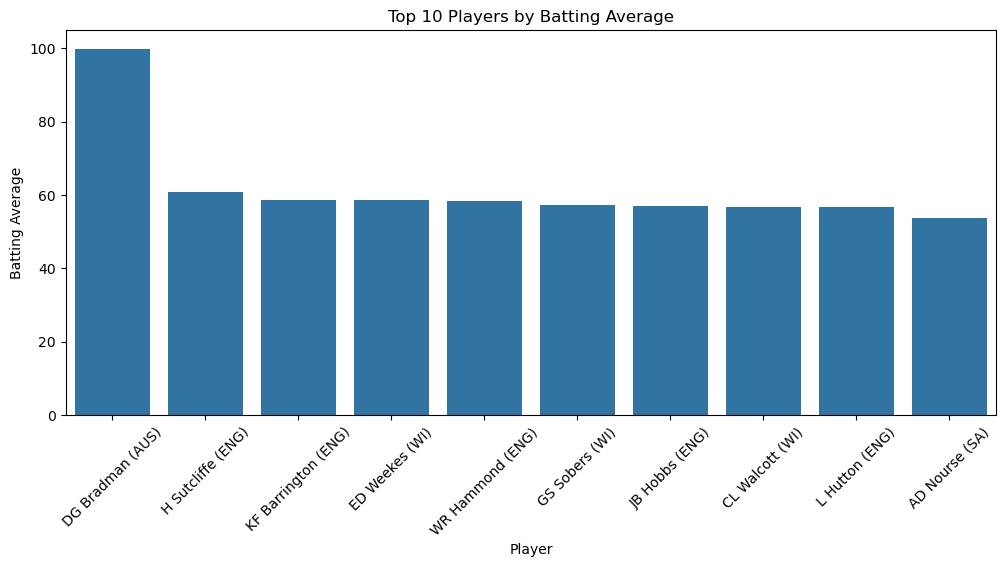

```python
top10 = df.sort_values(by='Average', ascending=False).head(10)
plt.figure(figsize=(12,5))
sns.barplot(x=top10['Player'], y=top10['Average'])
plt.xticks(rotation=45)
plt.ylabel('Batting Average')
plt.title('Top 10 Players by Batting Average')
plt.show()
```

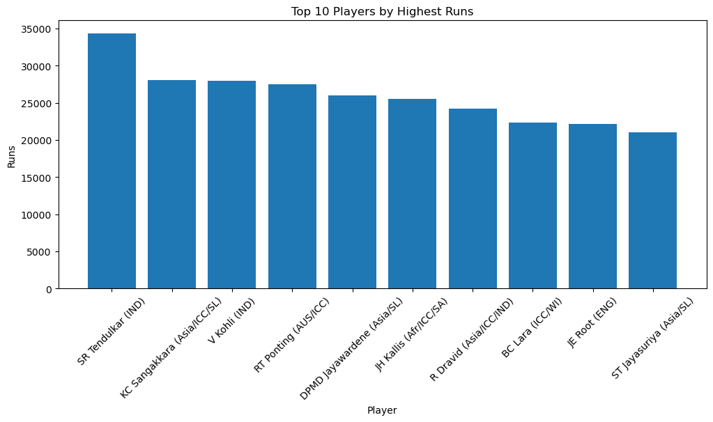

```python
top10_runs = df.sort_values(by='Runs', ascending=False).head(10)
plt.figure(figsize=(12,5))
plt.bar(top10_runs['Player'], top10_runs['Runs'])
plt.xticks(rotation=45)
plt.xlabel('Player')
plt.ylabel('Runs')
plt.title('Top 10 Players by Highest Runs')
plt.show()
```

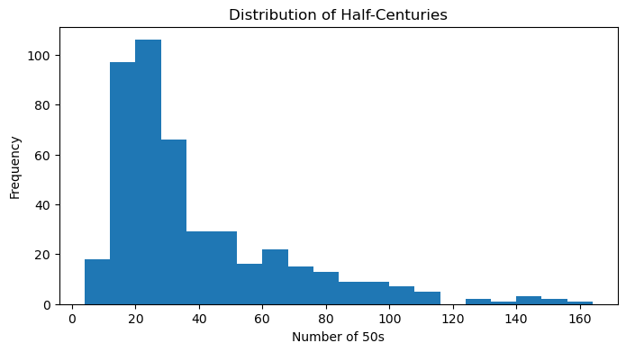

```python
plt.figure(figsize=(8,4))
plt.hist(df['50s'], bins=20)
plt.xlabel('Number of 50s')
plt.ylabel('Frequency')
plt.title('Distribution of Half-Centuries')
plt.show()
```

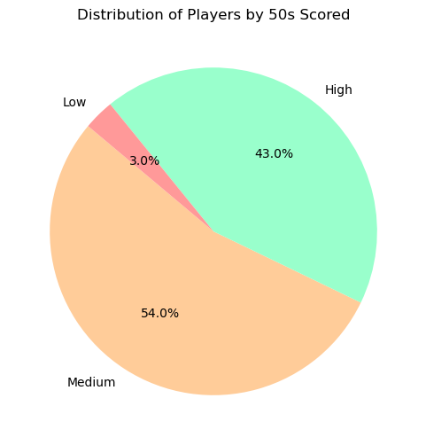

```python
df['50s_group'] = pd.cut(df['50s'], bins=[0,10,30,100], labels=['Low','Medium','High'])
counts50 = df['50s_group'].value_counts()

plt.figure(figsize=(6,6))
plt.pie(counts50, labels=counts50.index, autopct='%1.1f%%', startangle=140, colors=['#ffcc99','#99ffcc','#ff9999'])
plt.title('Distribution of Players by 50s Scored')
plt.show()
```

# Bivarient

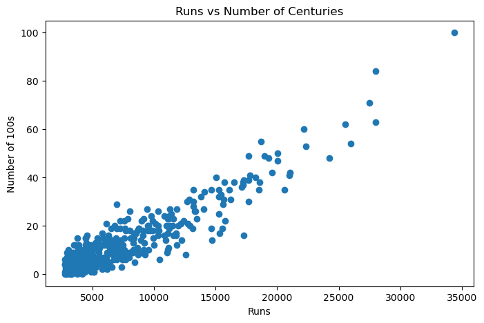

```python
plt.figure(figsize=(8,5))
plt.scatter(df['Runs'], df['100s'])
plt.xlabel('Runs')
plt.ylabel('Number of 100s')
plt.title('Runs vs Number of Centuries')
plt.show()
```

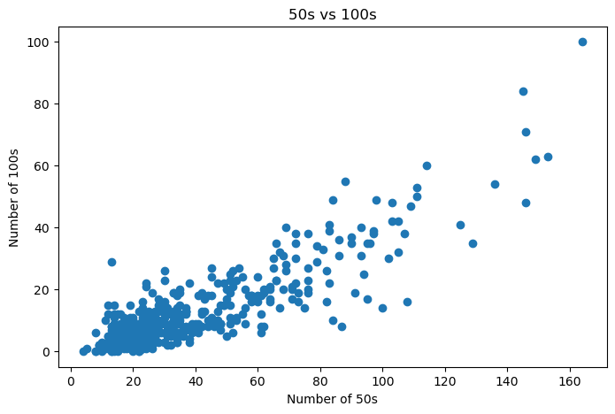

```python
plt.figure(figsize=(8,5))
plt.scatter(df['50s'], df['100s'])
plt.xlabel('Number of 50s')
plt.ylabel('Number of 100s')
plt.title('50s vs 100s')
plt.show()
```

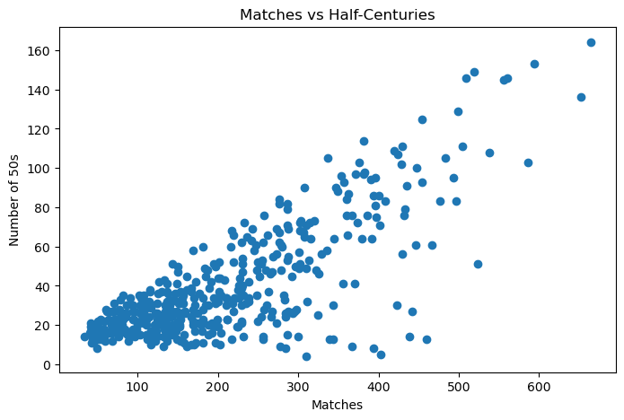

```python
plt.figure(figsize=(8,5))
plt.scatter(df['Matches'], df['50s'])
plt.xlabel('Matches')
plt.ylabel('Number of 50s')
plt.title('Matches vs Half-Centuries')
plt.show()
```

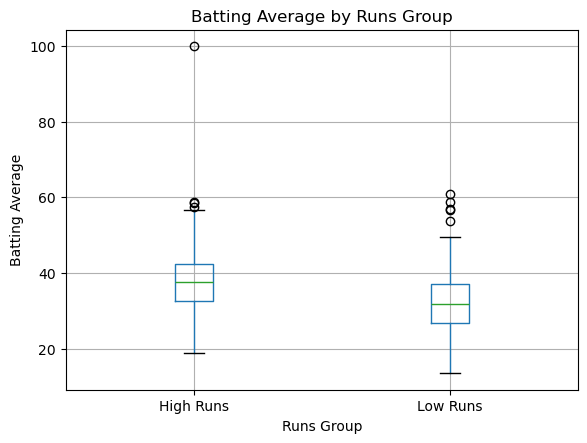

```python
median_runs = df['Runs'].median()
df['Runs_Group'] = ['High Runs' if r >= median_runs else 'Low Runs' for r in df['Runs']]

plt.figure(figsize=(6,5))
df.boxplot(column='Average', by='Runs_Group')
plt.xlabel('Runs Group')
plt.ylabel('Batting Average')
plt.title('Batting Average by Runs Group')
plt.suptitle('')
plt.show()
```

# Multi Varient

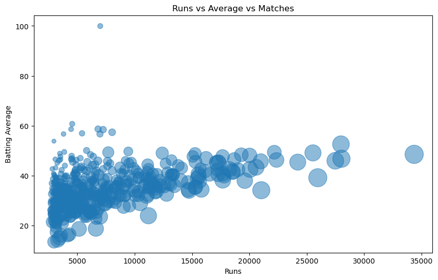

```python
plt.figure(figsize=(10,6))
plt.scatter(
    df['Runs'],
    df['Average'],
    s=df['Matches'],
    alpha=0.5
)
plt.xlabel('Runs')
plt.ylabel('Batting Average')
plt.title('Runs vs Average vs Matches')
plt.show()
```

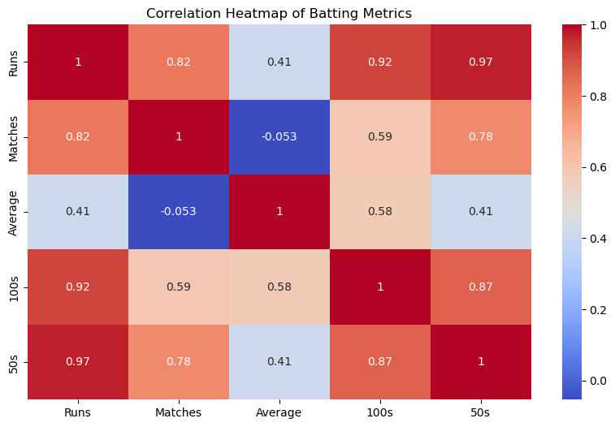

```python
import seaborn as sns

plt.figure(figsize=(10,6))
sns.heatmap(
    df[['Runs','Matches','Average','100s','50s']].corr(),
    annot=True,
    cmap='coolwarm'
)
plt.title('Correlation Heatmap of Batting Metrics')
plt.show()
```

[figure not shown]

```python
df=pd.read_csv(r"C:\Users\chintha kalyan\innomatics\espncricket123.csv")
df
```

|  | Player | Span | Matches | Innings | Runs | Average | highestscore | 100s | 50s |
| --- | --- | --- | --- | --- | --- | --- | --- | --- | --- |
| 0 | SR Tendulkar (IND) | 1989-2013 | 664 | 782 | 34357 | 48.52 | 248* | 100 | 164 |
| 1 | KC Sangakkara (Asia/ICC/SL) | 2000-2015 | 594 | 666 | 28016 | 46.77 | 319 | 63 | 153 |
| 2 | V Kohli (IND) | 2008-2025 | 556 | 623 | 27975 | 52.58 | 254* | 84 | 145 |
| 3 | RT Ponting (AUS/ICC) | 1995-2012 | 560 | 668 | 27483 | 45.95 | 257 | 71 | 146 |
| 4 | DPMD Jayawardene (Asia/SL) | 1997-2015 | 652 | 725 | 25957 | 39.15 | 374 | 54 | 136 |
| ... | ... | ... | ... | ... | ... | ... | ... | ... | ... |
| 445 | BM McMillan (SA) | 1991-1998 | 116 | 114 | 2809 | 32.66 | 127 | 4 | 13 |
| 446 | GH Dockrell (IRE) | 2010-2025 | 284 | 197 | 2806 | 21.41 | 91* | 0 | 8 |
| 447 | Haris Sohail (PAK) | 2013-2023 | 75 | 84 | 2806 | 36.92 | 147 | 4 | 19 |
| 448 | MAK Pataudi (IND) | 1961-1975 | 46 | 83 | 2793 | 34.91 | 203* | 6 | 16 |
| 449 | Sabbir Rahman (BAN) | 2014-2022 | 125 | 128 | 2791 | 24.48 | 102 | 1 | 14 |

450 rows × 9 columns

# Hypothesis Testing

```python
import pandas as pd
import matplotlib.pyplot as plt
import seaborn as sns
import numpy as np
from scipy.stats import ttest_ind
```

```python
median_runs = df['Runs'].median()
high_avg = df[df['Runs'] >= median_runs]['Average']
low_avg  = df[df['Runs'] < median_runs]['Average']
t_stat, p_value = ttest_ind(high_avg, low_avg)
print("T-statistic:", t_stat)
print("P-value:", p_value)
```

```
T-statistic: 7.078553554557633
P-value: 5.659126848289658e-12
```

```python
from scipy.stats import pearsonr
corr, p_value = pearsonr(df['Runs'], df['100s'])
print("Correlation:", corr)
print("P-value:", p_value)
```

```
Correlation: 0.9211046744967063
P-value: 1.16544803553803e-185
```

```python
from scipy.stats import ttest_ind
median_100s = df['100s'].median()
high_100s = df[df['100s'] >= median_100s]['50s']
low_100s  = df[df['100s'] < median_100s]['50s']
t_stat, p_value = ttest_ind(high_100s, low_100s)
print("T-statistic:", t_stat)
print("P-value:", p_value)
```

```
T-statistic: 14.245977556716435
P-value: 3.012711731881175e-38
```

### Effect of Runs & Matches on Batting Average

```python
import statsmodels.api as sm
from statsmodels.formula.api import ols

df['Runs_Group'] = pd.qcut(df['Runs'], q=2, labels=['Low Runs', 'High Runs'])
df['Matches_Group'] = pd.qcut(df['Matches'], q=2, labels=['Low Matches', 'High Matches'])

model = ols(
    'Average ~ C(Runs_Group) + C(Matches_Group) + C(Runs_Group):C(Matches_Group)',
    data=df
).fit()

anova_table = sm.stats.anova_lm(model, typ=2)
print(anova_table)
```

```
                                      sum_sq     df           F        PR(>F)
C(Runs_Group)                    8118.881055    1.0  146.477738  2.362573e-29
C(Matches_Group)                 5176.205277    1.0   93.387110  3.476729e-20
C(Runs_Group):C(Matches_Group)    246.651777    1.0    4.449997  3.545793e-02
Residual                        24720.623044  446.0         NaN           NaN
```

### Runs Group vs 100s Group

```python
from scipy.stats import chi2_contingency
import pandas as pd

df['Runs_Group'] = pd.cut(df['Runs'], bins=2, labels=['Low Runs', 'High Runs'])
df['Hundreds_Group'] = pd.cut(df['100s'], bins=2, labels=['Low 100s', 'High 100s'])

contingency = pd.crosstab(df['Runs_Group'], df['Hundreds_Group'])
print(contingency)

chi2, p_value, dof, expected = chi2_contingency(contingency)

print("Chi-square:", chi2)
print("P-value:", p_value)
```

```
Hundreds_Group  Low 100s  High 100s
Runs_Group
Low Runs             431          0
High Runs             10          9
Chi-square: 184.8577359873
P-value: 4.215562375334192e-42
```